# Grupo Bimbo Inventory Demand (maximize sales and minimize returns of bakery goods)

Matheus C. Andrade

6/29/2021

# Data Modelling

### Setting work directory and loading libraries

```r
setwd("~/Development/DataScienceAcademy/FCD/BigDataRAzure/ProjetoFinal/Grupo-Bimbo-Inventory-Demand/Modelling_and_Evaluation")
getwd()
```

```
## [1] "/home/matheus/Development/DataScienceAcademy/FCD/BigDataRAzure/ProjetoFinal/Grupo-Bimbo-Inventory-Demand/Modelling_and_Evaluation"
```

```r
## Libraries
library(data.table)
library(dplyr)
library(caret)
library(xgboost)
library(Metrics) #rmsle function
```

## 1.0 Loading Datasets

```r
# 1.1 Loading 'train' dataset:
train <- fread("../Datasets/train.csv", header=T)
#train <- fread("../Datasets/train_sample.csv", header=T)
# train_orig <- fread("../Datasets/train.csv", header=T)
#
# # Checking the quantity of records in dataset:
# dim(train_orig)[1]
#
# # Sets a seed to allow the same experiment result to be reproducible:
# set.seed(123);
# # Creating a random sample with 1kk rows from train dataset
# train <- train_orig[sample(nrow(train_orig), size=1000000), ]
#
# # Removing the complete train dataset
# rm(train_orig)

# 1.2 Loading 'test' dataset:
test <- fread("/home/matheus/Development/DataScienceAcademy/FCD/BigDataRAzure/ProjetoFinal/Projeto2/Datasets/test.csv", header=T)
```

## 2.0 Predictive Analytics

### 2.1 Feature Selection

```r
names(test)
```

```
## [1] "id"          "Semana"      "Agencia_ID"  "Canal_ID"    "Ruta_SAK"
## [6] "Cliente_ID"  "Producto_ID"
```

```r
# Since the variables Venta_uni_hoy, Venta_hoy, Dev_uni_proxima and Dev_proxima are not present in the test dataset and we won't use them for transformation, so we will exclude them from the training dataset.
train <- train %>% select(Semana, Agencia_ID, Canal_ID, Ruta_SAK, Cliente_ID, Producto_ID, Demanda_uni_equil)
```

### 2.2 1st Feature Engineering - transforming the target variable

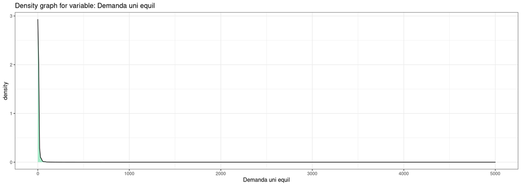

```r
# Do you remember in EDA that there is a distortion in the data distribution of the variable Demand_uni_equil?
train %>%
    ggplot(aes(x = Demanda_uni_equil)) +
    geom_density(fill = '#A6EBC9') +
    theme_bw() +
    labs(title = 'Density graph for variable: Demanda uni equil') +
    xlab('Demanda uni equil')
```

```r
# So, that's a problem for data modelling.
```

To reduce irregularity in the data and make the patterns of this variable more visible we will use the log1p (or log(x + 1)) transformation function. And further on, we will also use the function expm1 (or exp(x) - 1) to carry out the inverse process of this transforming.

```r
# Calculates the natural logarithm of each value of the variable Demand_uni_equil + 1 unit, that is, log(Demand_uni_equil + 1):
train$Demanda_uni_equil <- log1p(train$Demanda_uni_equil)
```

For more information on how the log function acts on skewed data see this [link](https://onlinestatbook.com/2/transformations/log.html). To better understand the functions log1p and expm1 see this [link](https://www.johndcook.com/blog/2010/06/07/math-library-functions-that-seem-unnecessary/).

We emphasize that the main reason for using the log1p function is there are null values within the variable data, which makes the use of the log function unfeasible because the [log(0) is an undefined value](https://www.rapidtables.com/math/algebra/logarithm/Logarithm_of_0.html).

```r
# Checking for null values for the variable Demanda_uni_equil:
prop.table(table(train$Demanda_uni_equil == 0))
```

```
##
##     FALSE      TRUE
## 0.9819788 0.0180212
```

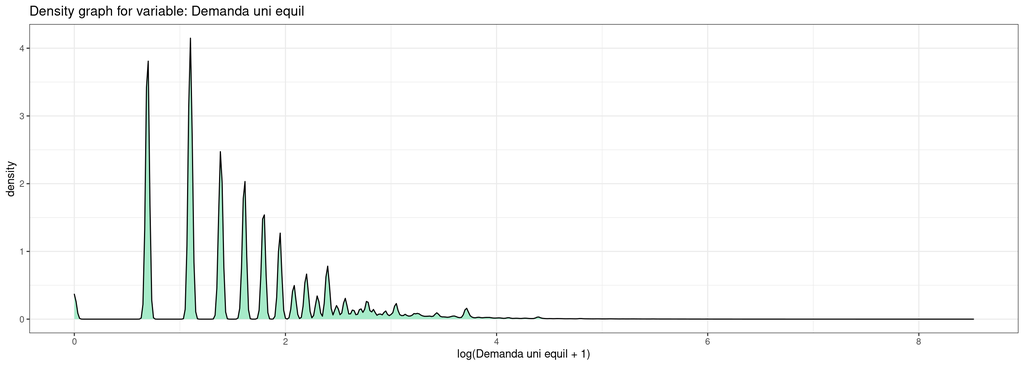

```r
# We find that approximately 1.8% of the data for the variable to be predicted is equal to 0. That's why we applied log1p function to the dataset.

# Visualize the effect of the transformation (log1p) applied on the data:
train %>%
    ggplot(aes(x = Demanda_uni_equil)) +
    geom_density(fill = '#A6EBC9') +
    theme_bw() +
    labs(title = 'Density graph for variable: Demanda uni equil') +
    xlab('log(Demanda uni equil + 1)')
```

We conclude that applying the log1p function decreased the distortion caused by outliers within the dataset of the variable to be predicted and this will help us to achieve better accuracy values in the models.

### 2.3 Joining training and test data in the same dataset

Our goal in this step is to create a single dataset containing both training data and test data. But, before we perform this action, we should note that there are exclusive variables for each of these datasets.

```r
# The test dataset has the variables 'id' and 'Demand_uni_equil' that are not contained in the training data and so we will create them for this dataset:
train$id <- 0
train$toTest <- 0

# To distinguish the records that belong to the training dataset from those that belong to the test data, we will create a binary variable named toTest (0: training data; 1:test data):
test$Demanda_uni_equil <- 0
test$toTest <- 1

# for the records of last week, ninth, let's merge them with the record of the test dataset:
data <- rbind(train[Semana == 9], test)
# the test data are in 'data' object joined with ninth week of training dataset,

# so, now we remove this object:
rm(test)
```

### 2.4 2nd Feature Engineering - creating new predictor variables

```r
# Training data records that have not been manipulated will be used in this step:
train <- train[Semana <= 8]

# Do you remember the correlation stage at EDA? So, now we will create for the model those variables that were better on correlation:
demand_mean_PC <- train %>%
  group_by(Producto_ID, Cliente_ID) %>%
  summarise_at(vars(Demanda_uni_equil),
               list(Mean_byPC = mean))
data <- merge(x=data,y=demand_mean_PC,by=c("Producto_ID","Cliente_ID"), all.x = TRUE)

demand_mean_ACR <- train %>%
  group_by(Agencia_ID, Canal_ID, Ruta_SAK) %>%
  summarise_at(vars(Demanda_uni_equil),
               list(Mean_byACR = mean))
data <- merge(x=data,y=demand_mean_ACR,by=c("Agencia_ID", "Canal_ID", "Ruta_SAK"), all.x = TRUE)

demand_mean_prod <- train %>%
  group_by(Producto_ID) %>%
  summarise_at(vars(Demanda_uni_equil),
               list(Mean_byProd = mean))
data <- merge(x=data,y=demand_mean_prod,by=c("Producto_ID"), all.x = TRUE)

demand_mean_client <- train %>%
  group_by(Cliente_ID) %>%
  summarise_at(vars(Demanda_uni_equil),
               list(Mean_byClient = mean))
data <- merge(x=data,y=demand_mean_client,by=c("Cliente_ID"), all.x = TRUE)


# let's look how the data are:
head(data)
```

```
##    Cliente_ID Producto_ID Agencia_ID Canal_ID Ruta_SAK Semana Demanda_uni_equil
## 1:         26       30235       2655        2     4189      9          4.574711
## 2:         26       31393       2061        2     7212      9          2.639057
## 3:         26       31518       2655        2     4189     10          0.000000
## 4:         26       31520       2655        2     4189     11          0.000000
## 5:         26       32962       2061        2     7212      9          2.397895
## 6:         26       34204       2061        2     7212      9          3.784190
##         id toTest Mean_byPC Mean_byACR Mean_byProd Mean_byClient
## 1:       0      0        NA   3.095841    3.117261      2.853926
## 2:       0      0  2.917141   2.828497    1.559129      2.853926
## 3: 1569352      1  2.397895   3.095841    2.514937      2.853926
## 4: 4728674      1        NA   3.095841    3.066581      2.853926
## 5:       0      0  1.386294   2.828497    2.635926      2.853926
## 6:       0      0  3.669958   2.828497    2.673286      2.853926
```

```r
# Note that as we started to evaluate the average values and quantities of each variable by grouping, the problem of the existence of products within the test data that are not present within the training data has been eliminated.

# removing no longer needed variables:
rm(demand_mean_PC, demand_mean_ACR, demand_mean_prod, demand_mean_client, train)
```

### 2.5 3rd Feature Engineering - transforming predictor variables

In this step we will scale the values of the predictor variables between 0 and 1.

```r
# Defining preprocessing method:
params <- preProcess(data[, !c('id', 'Demanda_uni_equil', 'toTest')], method = 'range')
# "range" method scales the data to be within rangeBounds. If new samples have values larger or smaller than those in the training set, values will be outside of this range.

# Transforming the data:
data <- predict(params, data)

# Let's see how the data turned out:
head(data)
```

```
##    Cliente_ID Producto_ID Agencia_ID Canal_ID  Ruta_SAK Semana
## 1:          0   0.6044119 0.06268003      0.1 0.4201023    0.0
## 2:          0   0.6275923 0.03858169      0.1 0.7233424    0.0
## 3:          0   0.6300945 0.06268003      0.1 0.4201023    0.5
## 4:          0   0.6301345 0.06268003      0.1 0.4201023    1.0
## 5:          0   0.6589999 0.03858169      0.1 0.7233424    0.0
## 6:          0   0.6838618 0.03858169      0.1 0.7233424    0.0
##    Demanda_uni_equil      id toTest Mean_byPC Mean_byACR Mean_byProd
## 1:          4.574711       0      0        NA  0.3824259   0.3979951
## 2:          2.639057       0      0 0.3436378  0.3494012   0.1990612
## 3:          0.000000 1569352      1 0.2824709  0.3824259   0.3210936
## 4:          0.000000 4728674      1        NA  0.3824259   0.3915245
## 5:          2.397895       0      0 0.1633048  0.3494012   0.3365408
## 6:          3.784190       0      0 0.4323192  0.3494012   0.3413108
##    Mean_byClient
## 1:     0.3432635
## 2:     0.3432635
## 3:     0.3432635
## 4:     0.3432635
## 5:     0.3432635
## 6:     0.3432635
```

### 2.6 Segmenting training and testing data

```r
# Obtaining train records:
train <- data %>%
  filter(toTest == 0) %>%
  select(-c(id, toTest))

# Obtaining test records:
test <- data %>%
  filter(toTest == 1) %>%
  select(-c(Demanda_uni_equil, toTest))

# now, data object will not be used more
rm(data)
```

### 2.7 Creating XGboost Model

We chose XGboost algorithm to create our predictive model because it has a good performance to generate the scores of the evaluation metric to be used and because it is considerably faster when compared to other algorithms.

```r
# Function to find the best parameters for XGboost algorithm. It generates various models and compares them.
getBetterXGboostParameters <- function(data, label, maxDepth = 10, nRounds = 100) {

  # Creating a dataframe to save model results.
  featuresXGboost <- data.frame()

  # auxiliary variable to monitoring the progress in the evaluation of the created models.
  count <- 0

  # it defines the total number of models to be created.
  total <- length(maxDepth) * length(nRounds)

  # Converting dataset variable data to DMatrix type (a dense matrix).
  dTrain <- xgb.DMatrix(
    data  = data,      # predictor variables
    label = label      # variable to be predicted.
  )

  # Specify the learning task and the corresponding learning objective (regression with squared log loss):
  obj = "reg:squaredlogerror"

  for(m in maxDepth) {
    for(r in nRounds) {
      # Sets a seed to allow the same experiment result to be reproducible:
      set.seed(12345)

      # Creating the model based on the XGboost algorithm:
      model_xgb <- xgb.train(
        data      = dTrain,   # defines the predictor variables and the variable to be predicted.
        objective = obj,      # regression with squared log loss as learning task
        max.depth = m,        # it defines the maximum size of the tree.
        nrounds   = r,        # it controls the maximum number of iterations.
      )

      # Performing prediction with the model based on the XGboost algorithm:
      pred <- predict(model_xgb, data)
      pred[pred < 0] <- 0

      # It stores in a dataframe the parameters used to create the models and their RMSLE metric score obtained:
      featuresXGboost <- rbind(featuresXGboost, data.frame(
        maxDepth = m,
        nRounds  = r,
        rmsle    = rmsle(label, pred))
      )

      # Increases the number of evaluated models.
      count <- count + 1

      # Print the results during evaluation
      print(paste(100 * count / total, '%, best rmsle: ', min(featuresXGboost$rmsle)))
    }
  }

  # Returns the dataframe with the results obtained from each model
  featuresXGboost

} # End getBetterXGboostParameters Function
```

The XGboost algorithm has the ability to handle NA values and so we will not transform the data to handle these apparitions. Then, we can create the model now.

```r
# Generating different models based on the XGboost algorithm and determining their scores for each RMSLE metric.
featuresXGboost <- getBetterXGboostParameters(
  data        = as.matrix(train %>% select(- Demanda_uni_equil)),
  label       = train$Demanda_uni_equil,
  maxDepth    = 13:14,
  nRounds     = 86:87
)
```

```
## [1] "25 %, best rmsle:  0.187554114763534"
## [1] "50 %, best rmsle:  0.187554069084898"
## [1] "75 %, best rmsle:  0.176710920818369"
## [1] "100 %, best rmsle:  0.176640239313067"
```

```r
# It returns the dataframe with the results obtained from each model:
featuresXGboost
```

```
##   maxDepth nRounds     rmsle
## 1       13      86 0.1875541
## 2       13      87 0.1875541
## 3       14      86 0.1767109
## 4       14      87 0.1766402
```

```r
# The best model in this case is:
featuresXGboost[which.min(featuresXGboost$rmsle), ] #head(sort(featuresXGboost$rmsle, decreasing = F), 1)
```

```
##   maxDepth nRounds     rmsle
## 4       14      87 0.1766402
```

```r
# so, it seems that the best model is in the 4th row;

# However, after using each of the above settings on kaggle, it was observed that the best result is in 2nd row.
featuresXGboost[2, ]
```

```
##   maxDepth nRounds     rmsle
## 2       13      87 0.1875541
```

```r
bestXGboost <- featuresXGboost[2, ]
```

Therefore, the best model is the 2nd row, since models registered after this row show lower performances because they begin overfitting.

```r
# Converting the data for  DMatrix type (a dense matrix):
xgb_train <- xgb.DMatrix(data = data.matrix(select(train, -Demanda_uni_equil)), # predictor variables.
                         label = train$Demanda_uni_equil)                       # variable to be predicted.

# Sets a seed to allow the same experiment result to be reproducible:
set.seed(12345)

# Creating the model based on the XGboost algorithm:
model_xgb <- xgboost(
  data      = xgb_train,             # it defines the predictor variables and the variable to be predicted.
  max.depth = bestXGboost$maxDepth,  # it defines the maximum size of the tree.
  nrounds   = bestXGboost$nRounds,   # it controls the maximum number of iterations.
)
# Performing prediction with the model based on the XGboost algorithm:
pred <- predict(model_xgb, as.matrix(test %>% select(- id)))
```

```r
# Converting the predicted results to the original scale of the target variable (exp(Demand_uni_equil) - 1):
pred <- expm1(pred)

# Turning any negative prediction into a null value:
pred[pred < 0] <- 0

# Saving the generated results to a CSV file:
d <- data.frame(id = as.integer(test$id), Demanda_uni_equil = pred)
fwrite(d, "completeTrainDataset_submit.csv")
```

### RMSLE metric scores on Kaggle

#### Complete train dataset:

More details (set.seed = 12345):

```r
featuresXGboostAndKaggle <- fread("featuresXGboostAndKaggle.csv")
featuresXGboostAndKaggle
```

```
##    maxDepth nRounds     rmsle KagglePublicScore KagglePrivateScore TheBestModel
## 1:       13      86 0.1875541           0.47611            0.45760           No
## 2:       13      87 0.1875541           0.47608            0.45756          Yes
## 3:       14      86 0.1767109           0.47684            0.45836           No
## 4:       14      87 0.1766402           0.47685            0.45836           No
```

## Get in touch with me

If you have any questions, suggestions or just want to exchange an idea about this project, don’t hesitate to get in touch with me!